# Creating a presence-absence raster from a shapefile

Amy Whitehead

19/04/2022

Bakc in 2013 I published a post with a little function for [creating presence-absence rasters from point data](https://amywhiteheadresearch.wordpress.com/2013/05/27/creating-a-presence-absence-raster-from-point-data/). I was in the midst of creating ~1000 species distribution models for Australian species and I needed something that I could easily automate in R.

Both R and my approach to working with spatial data have changed a lot in the last nine years, particularly with excellent new packages such as [`sf`](https://r-spatial.github.io/sf/) and [`fasterize`](https://cran.r-project.org/web/packages/fasterize/vignettes/using-fasterize.html). This post is a brief update to a new option for creating presence-absence rasters, prompted by a reader’s question.

The steps are essentially the same but I’ve adopted some new packages (`sf` and `fasterize`) that make life easier.  
1. Create an sf point data set from a dataframe of point locations using `st_as_sf`.  
2. Convert the points to polygons using `st_buffer`. This step is necessary as `fasterize` currently doesn’t work with points. For this simple example, I’ve elected to leave my points in WGS84, which means I get a warning that st_buffer doesn’t work properly with lat/long data. I could have used `st_transform` to convert it to a different projection before using `st_buffer`.  
3. Convert the polygons to raster using `fasterize` and then `mask` out the ocean.

```r
require(biomod2)
require(dplyr)
require(raster)
require(fasterize)
require(sf)

select <- dplyr::select

# read in a raster of the world
world <- raster(system.file( "external/bioclim/current/bio3.grd",package="biomod2"))

# read in species point data and extract data for foxes
mammals <- read.csv(system.file("external/species/mammals_table.csv", package="biomod2"),
                    row.names = 1)

head(mammals)
```

```
  X_WGS84  Y_WGS84 ConnochaetesGnou GuloGulo PantheraOnca PteropusGiganteus
1   -94.5 82.00001                0        0            0                 0
2   -91.5 82.00001                0        1            0                 0
3   -88.5 82.00001                0        1            0                 0
4   -85.5 82.00001                0        1            0                 0
5   -82.5 82.00001                0        1            0                 0
6   -79.5 82.00001                0        1            0                 0
  TenrecEcaudatus VulpesVulpes
1               0            0
2               0            0
3               0            0
4               0            0
5               0            0
6               0            0
```

```r
# extract fox data from larger dataset and keep only the x and y coordinates
fox_data <- mammals %>%
  # keep only the spatial data and foxes
  select(X_WGS84,Y_WGS84,VulpesVulpes) %>%
  # keep only the presence points for foxes
  filter(VulpesVulpes %in% 1) %>%
  # convert to an sf points object projected in WGS84
  st_as_sf(coords=c("X_WGS84","Y_WGS84"),
           crs = 4326) %>%
  # convert to an sf polygon object by buffering the points
  st_buffer(1)
```

```
Warning in st_buffer.sfc(st_geometry(x), dist, nQuadSegs, endCapStyle =
endCapStyle, : st_buffer does not correctly buffer longitude/latitude data
```

```r
head(fox_data)
```

```
Simple feature collection with 6 features and 1 field
Geometry type: POLYGON
Dimension:     XY
Bounding box:  xmin: -95.5 ymin: 72.00001 xmax: -75.5 ymax: 74.00001
Geodetic CRS:  WGS 84
  VulpesVulpes                       geometry
1            1 POLYGON ((-93.5 73.00001, -...
2            1 POLYGON ((-87.5 73.00001, -...
3            1 POLYGON ((-84.5 73.00001, -...
4            1 POLYGON ((-81.5 73.00001, -...
5            1 POLYGON ((-78.5 73.00001, -...
6            1 POLYGON ((-75.5 73.00001, -...
```

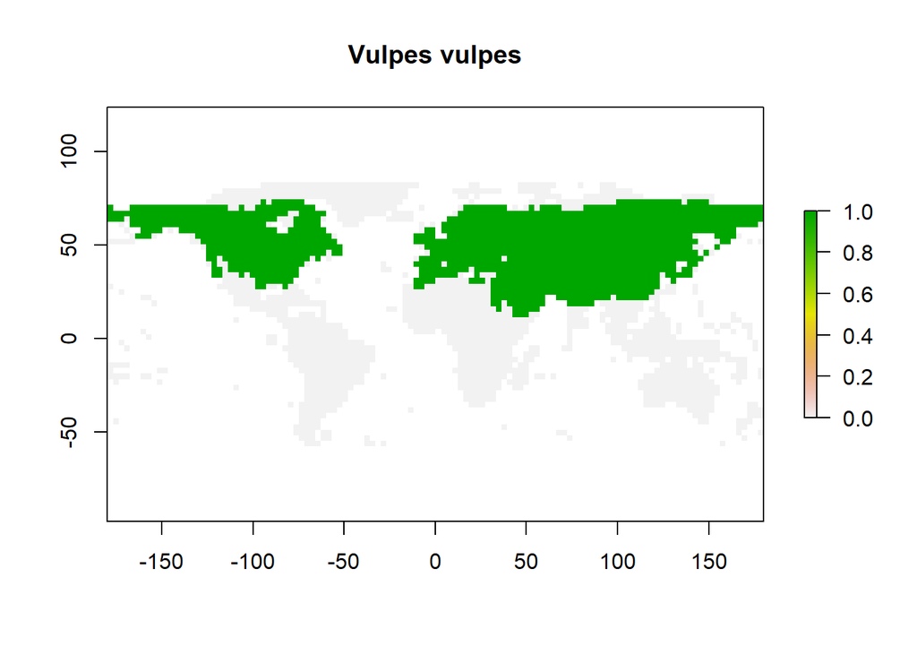

```r
fox_raster <- fasterize(fox_data, world,
                        # select the column to use in the raster
                        field = "VulpesVulpes",
                        # set the value of the background points
                        background = 0) %>%
  # only retain values in non-NA cells in the original raster
  mask(world)

plot(fox_raster,main="Vulpes vulpes")
```

In this plot, the presences (1) are shown in green and the absences (0) in light grey. Now I could have kept the absences in the original dataset and created the raster without using the mask but I wanted to demonstrate what you would need to do if your dataset doesn’t include absence data (which seems to be the most typical scenario).

*Pro tip*: don’t forget to check that your species point data and raster are in the same projection and that they actually overlap before you get started.

Hopefully this is helpful. But, as always, there are many ways to do things in R and this may not be the most efficient method. I’d be interested to know how else folks are doing this sort of thing.